# Probability and Statistics Fundamentals (Session 2)

# 4 Joint Distributions and Conditional Distributions

We often have to deail with more than just one variable in applied econometrics. For example, we could be interest in the probability that a person is between $170cm$ and $180cm$ tall *and* weighs between $60kg$ and $90kg$ (this is important for shoe manufacturers). We could also be interested in the probability of getting a $6$ with one throw of a die given the die is red instead of blue (comes in handy at the casino).

## 4.1 Joint Distributions

### 4.1.1 The discrete case

Let $X$ be a random variable for the throw of a die with equal chances to every side, and $Y$ a random variable for the color (blue, red) of the die. Throwing a random die would lead us to the joint probability density function of $(X,Y)$:
$$f_{X,Y}(x,y) = P(X=x, Y=y)$$
.

It is quite easy to obtain the joint pdf of $X$ and $Y$ if they are independent. $X$ and $Y$ are independent if:
$$f_{X,Y}(x,y) = f_X(x)f_Y(y)$$
In other words, they are independent if the die side thrown does not depend on the color of the die. In the discrete case, it is the same as
$$P(X=x, Y=y) = P(X=x)P(Y=y)\text{,}$$
that is, the probability that the die is read and you throw a 6 is the product of the probability of throwing a 6 and of the die being red. Since we know these probabilities, we can calculate: $\frac{1}{6} \times \frac{1}{2} = \frac{1}{12}$.

### 4.1.2 The continuous case

By taking the integral of a joint pdf of continous variables, we can get the probability that X and Y fall in a certain interval:
$$P(a \leq X \leq b, c \leq Y \leq d) = \int_a^b \int_c^df_{X,Y}(x,y)dydx$$
If you have any given functions, it is quite easy (as with the normal distribution) and can be done by hand (might in some cases be easier than doing it with r). A continuous joint pdf could look like this ($X$ = height, $Y$ = weight; this is a bad example because obviously weight is dependent from height).

```r
library(MASS)
library(threejs)
# Lets assume different standard deviations for height
# so that we are only looking at grown men and women
mu = c(177, 70); names(mu) = c("X", "Y")
stdevs = c(4, 5); names(stdevs) = names(mu)
cormatrix = matrix(c(1,0.9,0.9,1), ncol=2)
b = stdevs %*% t(stdevs)
varcovmat = b*cormatrix
colnames(varcovmat) = rownames(varcovmat) = names(mu)
obs = mvrnorm(n=10000, mu=mu, Sigma=varcovmat, empirical=T)
obs.kde = kde2d(obs[,1], obs[,2], n=100)

x = obs.kde$x; y = obs.kde$y; z = obs.kde$z
xx = rep(x, times=length(y))
yy = rep(y, each=length(x))
zz = z; dim(zz) = NULL
ra = ceiling(16*zz/max(zz))
col = rainbow(16, 2/3)
scatterplot3js(x=xx, y=yy, z=zz, size=0.4, color=col[ra], bg="white")
```

[interactive chart not shown]

## 4.2 Conditional Distributions

When we are interested in the probability of a specific outcome given we observed another specific outcome, we might want to take a look at the conditional distribution of $Y$ given $X$, or rather, at the **conditional probability density function**:
$$\frac{f_{Y|X}(y|x)}{f_X(x)}$$
For the discrete case follows:
$$f_{X|Y}(y|x) = P(Y=y|X=x)$$
When $X$ and $Y$ are independent, it follows from $f_{X,Y}(x,y) = f_X(x)f_Y(y)$ that
$$f_{X|Y}(y|x) = f_Y(y)$$

$f_{X,Y}(x,y) = f_X(x)f_Y(y)$

# 5 Features of Probability Distributions

## 5.1 Central Tendency: The Expected Value

The most commonly used feature of a probability distribution is the *expected value*. It splits the probability under the *pdf* in half.

> The expected value is the value from a probability distribution, for which the probabilities of another value being greater or smaller than it are exactly equal.

For example, we simulate a random variable $R$ from a standard normal distribution. First, we simulate the variable and draw a histogram with the arithmetic mean:

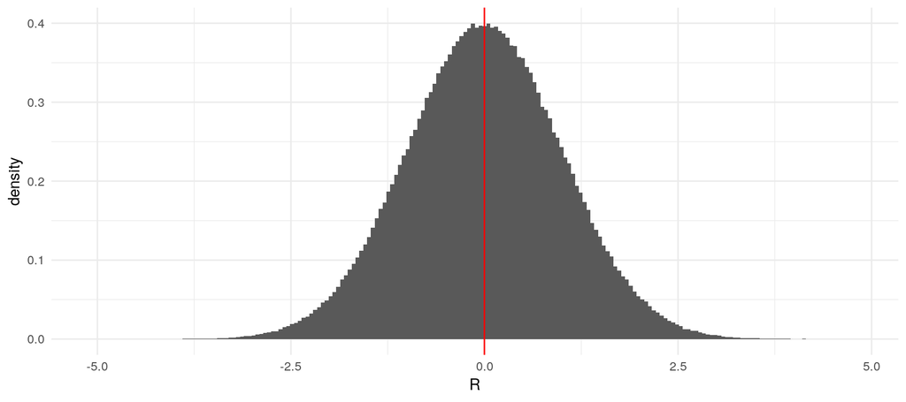

```r
library(ggplot2)
set.seed(1337) #seed for reproducibility
data <- data.frame(R = rnorm(n = 1000000))

ggplot(data, aes(x = R)) +
  geom_histogram(aes(y = ..density..), bins = 200) +
  geom_vline(xintercept = mean(data$R), color="red") +
  theme_minimal()
```

It looks like the area to the left of the mean is the same size at the area on the right side. Let’s check that:

```r
A <- numeric() # Variable for storing the area sizes

A[1] <- (sum (abs (data$R[data$R < mean(data$R)]))) /sum(abs(data$R)) # Area to the left of the mean in percent
A[2] <- (sum (abs (data$R[data$R > mean(data$R)]))) /sum(abs(data$R)) # Area to the right of the mean in percent

print(A)
```

```
## [1] 0.5007953 0.4992047
```

As we can see (and calculate), the area sizes are very similar, meaning htat half of the probability mass is on each side of the mean. Notice that since we’re in a simulation context, the areas are not *exactly* the same.

### 5.1.1 Useful Rules for Expected Values

For any constants $a$ and $b$ and a random variable $X$, the following rules apply:

- The expected value of a constant is the constant
  $$\mathbb{E}[c] = c$$
- The expected value of a linear function of a random variable is the linear function of the expected value of the variable
  $$\mathbb{E}[aX+b] = a\mathbb{E}[X] + b$$
- The expected value of a sum of random variables is the sum of the expected values of these random variables:
  $$\mathbb{E}\left[ \sum_{i=1}^n a_iX_i \right] = \sum_{i=1}^n \mathbb{E}[a_iX_i] = \sum_{i=1}^n a_i \mathbb{E}[X_i]$$
- For a variable $Y$ that is independent of $X$ it holds that:
  $$\mathbb{E}[XY] = \mathbb{E}[X] \mathbb{E}[X]$$
- The population mean is often denoted by $\mu$ or $\mu_X$ instead of $\mathbb{E}[X]$

## 5.2 Variablity: Variance and Standard Deviation

The central tendendcy tells us, around which value the outcomes of the random variable cluster, but it is also important to get a measure on how far they *spread around the mean*. The variance and standard deviation are measures for this.

You can see this notion of *distance from the mean* in the definition of the variance:

$$Var[X] = \mathbb{E} \left[ \left( X - \mathbb{E} [X] \right) ^2 \right]$$

The deviation from the expected value $(X - \mathbb{E}[X])$ is squared in order to prevent perfect cancellation of deviations, since:
$$\mathbb{E} \left[(X - \mathbb{E}[X]) \right] = \mathbb{E}[X] - \mathbb{E}[X] = 0$$

### 5.2.1 Useful Rules for Variances

For any constants $a$ and $b$ and a random variable $X$, the following rules apply:

- Alternative representation
  $$Var[X] = \mathbb{E} \left[ X^2 \right] - \mathbb{E}[X]^2$$
- Variance of a constant is zero:
  $$Var[c] = 0$$
- Variance of a linear combination:
  $$Var[aX+b] = a^2 Var[X]$$
- The population variance is often denoted by $\sigma^2$ or $\sigma_X^2$ instead of $Var[X]$.

### 5.2.2 The Standard Deviation

If we change the unit of measurement of $X$ by $a = 1000$, e.g. from kilometers to meters, the variance increases linearly by $a^2 = 1000 * 1000$ (see rules above). Since this makes it difficult to compare the variability of different variables, we use the standard deviation, which is the positive part of the square root of the variance:

$$sd[X] = + \sqrt{Var[X]}$$
For any constants $a$ and $b$ and a random variable $X$, it has the following useful properties: - Standard deviation of a linear combination:
$$sd[a X + b] = |a| sd[X]$$

- The standard deviation is often denoted by $\sigma$ or $\sigma_X$ instead of $sd[X]$.

## 5.3 Standardisation of Variables

Using the properties of the expected value and variance, we can transform any variable to a standardised variable with mean 0 and standard deviation 1:
$$Z := \frac{X-\mu}{\sigma}$$

We can demonstrate this with a short simulation. In the following we simulate a random variable $X$ from a normal distribution, that has mena $3$ and standard deviation $1.5$

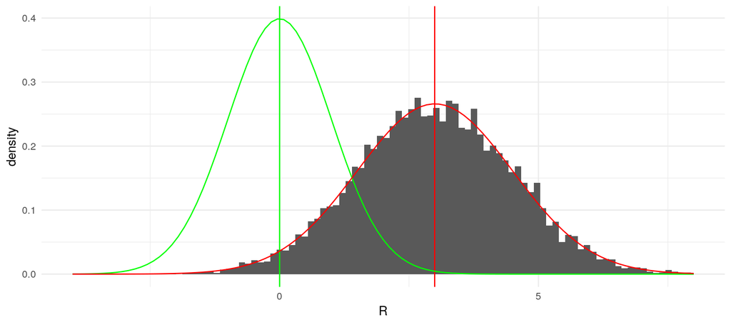

```r
library(ggplot2)
set.seed(1337) #seed for reproducibility
data_st <- data.frame(R = rnorm(n = 10000, mean = 3, sd = 1.5))

ggplot(data_st, aes(x = R)) +
  geom_histogram(aes(y=..density..),bins = 100) +
  geom_vline(xintercept = mean(data_st$R), color="red") +
  geom_vline(xintercept = 0, color="green") +
  stat_function(fun = dnorm, color = "green", args = list(mean = 0, sd = 1))+
  stat_function(fun = dnorm, color = "red", args = list(mean = 3, sd = 1.5)) +
  xlim(c(-4,8)) +
  theme_minimal()
```

The green lines indicate a standard normal distribution with $\mu = 0$ and $\sigma = 1$. Our simulated varaible clearly deviates from it. If we now transform $X$ according to the formula above, the result yields:

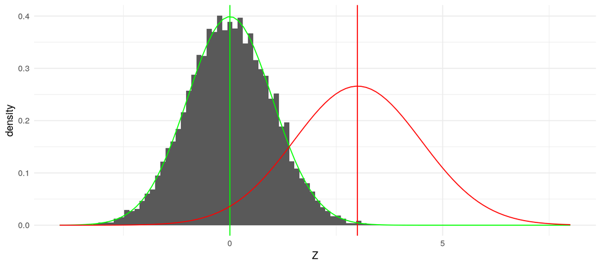

```r
data_st$Z <- (data_st$R - mean(data_st$R)) / sd(data_st$R)

ggplot(data_st, aes(x = Z)) +
  geom_histogram(aes(y=..density..),bins = 100) +
  geom_vline(xintercept = mean(data_st$R), color="red") +
  geom_vline(xintercept = 0, color="green") +
  stat_function(fun = dnorm, color = "green", args = list(mean = 0, sd = 1))+
  stat_function(fun = dnorm, color = "red", args = list(mean = 3, sd = 1.5)) +
  xlim(c(-4,8)) +
  theme_minimal()
```

## 5.4 Association: Covariance and Correlation

The covariance captures the joint variation of two random variables. It allows us to get a sense of the relationship of them, e.g. $X$ is always high when $Y$ is. This can be visualised graphically:

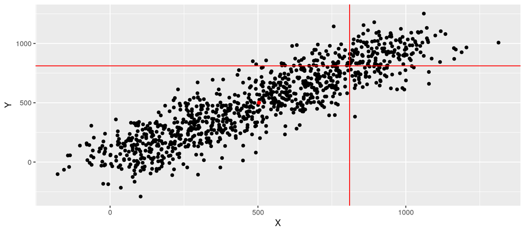

```r
library(ggplot2)
set.seed(1337)
data_cov <- data.frame(X = 1:1000 + rnorm(1000, sd = 100),
                       Y = 1:1000 + rnorm(1000, sd = 100))

ggplot(data_cov, aes(x = X, y = Y)) +
  geom_point() +
  geom_point(aes(x = mean(X), y = mean(Y)), color ="red") +
  geom_vline(xintercept = mean(data_cov$X) + sd(data_cov$X), color = "red") +
  geom_hline(yintercept = mean(data_cov$Y) + sd(data_cov$Y), color = "red")
```

We can easily see that $X$ and $Y$ have a strong relationship. We can stat that: when the deviation of $X$ (vertical line) from its mean (red dot) is high, the same can be said about the deviation of $Y$ (horizontal line).

Expressing this relation of deviations from the mean mathematically yields us the formula of the covariance:

$$Cov[X,Y] = \mathbb{E} \left[ (X - \mathbb{E}[X]) (Y - \mathbb{E}{Y} ) \right]$$

### 5.4.1 Useful Rules for Covariances

For any constants $a$ and $b$ and random variables $X$, and $Y$ the following rules apply:

- Alternative representations:
  $$\begin{aligned}
  Cov[X,Y] &= \mathbb{E}[XY] - \mathbb{E}[X] \mathbb{E}[Y] \\
  &= \mathbb{E}[(X -\mathbb{E}[X])Y] \\
  &= \mathbb{E}[X (Y -\mathbb{E}[Y])] \\
  \end{aligned}$$
- Covariance given independence of $X$ and $Y$:
  $$\begin{aligned}
  Cov[X,Y] &= \mathbb{E}[XY] - \mathbb{E}[X] \mathbb{E}[Y] \\
  &= 0 & \text{since } \mathbb{E}[XY] = \mathbb{E}[X] \mathbb{E}[X]
  \end{aligned}$$
- Variance of linear combinations:
  $$Cov[a_1 X + b_1, a_2Y + b_2] = a_1 a_2 Cov[X,Y]$$
- The boundary of the covariance of two random variables (its most extreme value) is given by the product of their standard deviations. This is also called the *Cauchy-Schwartz Inequality*:
  $$|Cov[X,Y]| \leq sd[X] sd[Y]$$
- The population covariance is usually denoted by $\sigma_{XY}$ instead of $Cov[X,Y]$

### 5.4.2 The Correlation Coefficient

The variance and standard deviation are both dependent on their units of measurement. To capture the *pure* relationsip betwee two random variables, we can get rid of this by using the *Cauchy-Schwartz Inequality* to normalise the variance. This yields us the correlation coefficient:

$$Corr[X,Y] = \frac{Cov[X,Y]}{sd[X] sd[Y]} = \frac{\sigma_{XY}}{\sigma_X \sigma_Y}$$

- The population correlation coefficient is usually denoted as $\rho$ or $\rho_{XY}$ instead of $Corr[X,Y]$

# 6 Simple Linear Regression and OLS

Now that we have learned about correlation and testing, we want to predict one variable from another. One simple way to do so is using linear regression. Simple linear regression (SLR) is about predicting a dependent variable (*regressand*) from one independent variable (*regressor*). A SLR model is given by:
$$y = \beta_0 + \beta_1x + \epsilon$$
where $y$ is the regressand and $x$ the regressor. $\epsilon$ denotes the error of the model, i.e. the residuals. Usually, researchers are interested in the amount of change in $y$ that occur when $x$ changes. As in any linear function, the rate of change is given by $\beta_1$. More formally:
$$\frac{\delta y}{\delta x} = \beta_1$$

## 6.1 Explanation by example

Now what does a linear regression model tell us? It tells us the relation between two variables and in the best case lets us predict the outcome if we have information about the independent variable. Assume that we have ten students who took exams in statistics and exams in econometrics. We know what grades were in percentage points. Now, we would like to predict the econometrics grade of any other student who took the statistics exam. Our model is as follows:

$$econgrade = \beta_0 + \beta_1statsgrade + \epsilon$$

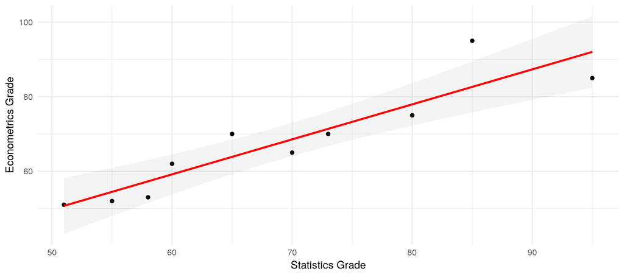

```r
library(ggplot2)
student_id = c(1,2,3,4,5)
x = c(95,85,80,73,70,65,60,58,55,51)
y = c(85,95,75,70,65,70,62,53,52,51)
grades_df = data.frame(student_id, x, y)
ggplot(grades_df, aes(x, y)) +
  geom_point() + labs(x="Statistics Grade", y="Econometrics Grade") + geom_smooth(
    method="lm", colour="red", se=T, alpha=0.1) + theme_minimal()
```

```r
summary(lm(y~x, data=grades_df))$coefficients
```

```
##              Estimate Std. Error   t value     Pr(>|t|)
## (Intercept) 2.8187652 10.0801739 0.2796346 0.7868516450
## x           0.9390352  0.1429934 6.5669819 0.0001753288
```

Judging from the graph, we have a clear linear relationship between the students’ statistics grades and the econometrics grades. In fact, our $\beta_1$, which is also the line’s slope, can be read from the summary ($0.939$) and from the Pr-column we also see that this estimate is different from zero (statistically significant, ***). A standard interpretation of this information would go as follows: “Ceteris paribus (with all else being equal, an increase of $1$ of the statistics grade implies an increase of $0.939$ of the econometrics grade. Given the t value which is above our given threshold of $1.96$, we would reject our null hypothesis that the influence of the statistics grade is equal to $0$.” We may go even as far and state that if a current student in the econometrics class has achieved a grade of $90$, he will approximately score $87$ points in the econometrics exam. But we have an essential problem with this interpretation, because we do not actually know that we have a causal relationship here or just a correlation. And right now, we do not know whether the line we drew represents the best guess for a prediction. To answer these questions, we need to know more.

## 6.2 Law of Iterated Expectations

We will shortly learn under which conditions we can assume that we’re looking at a causal relationship of $x$ on $y$. But before we do that, we need to know and understand the Law of Iterated Expectations (LEI). It states that the Expectation of $y$ given $x$ is equal to the expectation of $y$:
$$\mathbb{E}\left[Y\right] = \mathbb{E}\left[\mathbb{E}\left[Y|X\right]\right]$$
To get an idea why this holds, consider a game of darts being played in another room and you want to guess the landing spot of a dart. Let $Y$ denote this spot. Without any prior information, our best guess for the value $Y$ takes on would be the center $c$ of the board:
$$\mathbb{E}\left[Y\right] = c$$
Now suppose that every time a dart is thrown, someone watching in the other room tells us whether the dart landed in the upper or lower half of the board. Let this be another random variable $X$. By the information of $X$ we can improve our guess for the landing spot - if $X = upper$, then our best guess for $Y$ might be the center of the upper half of the board, $\mathbb{E}\left[Y|X = \text{upper}\right] = c^{\text{upper}}$, if $X = lower$, then our best guess for $Y$ would be the center of the lower half of the board, $\mathbb{E}\left[Y|X = \text{lower}\right] = c^{\text{lower}}$ Thus, the expectation of $Y$ conditional on $X$ depends on whether $X = up$ or $X = low$. But since $X$ is a random variable, $\mathbb{E}\left[Y|X\right]$ is also a random variable. When iterating Expectations like $\mathbb{E}\left[\mathbb{E}\left[Y|X\right]\right]$ we take expectations over the random variable $\mathbb{E}\left[Y|X\right]$, i.e., averaging the two best guesses of $X$ (upper and lower). When averaging those guesses proportional to how likely each $X$ outcome will be, then we expect that the averaged guess $\mathbb{E}\left[\mathbb{E}\left[Y|X\right]\right]$ agrees with the overall “direct” best guess $\mathbb{E}\left[Y\right]$

Credits to Jimmy Jin for the great intuition behind the LEI.

## 6.3 Causal interpretation

For a regression to be more than a simple correlation, one has to make assumptions how $x$ is related to the error term $\epsilon$. For causal interpretations, $x$ must not include information about $\epsilon$, that is, they must not be correlated. If they would be correlated, it is still possible that something else than $x$ predicts $y$. Mathematically speaking:
$$\mathbb{E} \left[\epsilon|x\right] = 0$$
This is called the **zero conditional mean assumption**. If it holds, we have **exogeneity**. In the example with the statistics and econometrics grade, we obviously do not have exogeneity, as the statistics grade is for example also highly correlated with the number of hours spend studying, that may also affect the econometrics grade. In this case, $\mathbb{E}\left[\epsilon|statsgrade\right] \neq 0$

Following from this and the Law of Iterated Expectations:
$$\begin{aligned}\mathbb{E} \left[\epsilon|x\right] &= \mathbb{E}\left[\epsilon\right] = 0\text{,}\end{aligned}$$
therefore:
$$\begin{aligned}Cov\left[x, \epsilon\right] &= \mathbb{E}\left[x\epsilon\right] - \mathbb{E}\left[X\right] \mathbb{E}\left[\epsilon\right] = 0\end{aligned}$$

Effectively, if the expected value of the error term is zero, the model is without error and thus average value of $y$ can be expressed as a linear function of $x$:
$$\begin{aligned}\mathbb{E}\left[y|x\right] &= \mathbb{E}\left[\beta_0 + \beta_1x + \epsilon|x\right] \\ &= \beta_0 + \beta_1x + \mathbb{E}\left[\epsilon|x\right] \\ &= \beta_0 + \beta_1x \end{aligned}$$

## 6.4 Assumptions

Note that this only holds as long as the the assumption of independence is met, i.e. $\frac{\delta \epsilon}{\delta x} = 0$